# Week 7: Building a ML End-to-End Project

# Evaluated algorithms: Box-Cox Transform

We know that some of the attributes have a skew and others perhaps have an exponential distribution. One option would be to explore squaring and log transforms respectively. Another approach would be to use a power transform and let it figure out the amount to correct each attribute. One example is the Box-Cox power transform. Let’s try using this transform to rescale the original dat and evaluate the effect on the same 6 algorithms. We will also leave in the centering and scaling for the benefit of the instance-based method.

# Estimate acuuracy of algorithms on transform dataset

```r
# Run algorithms using 10-fold cross validation

trainControl <- trainControl(method = "repeatedcv", number = 10, repeats = 3)

metric <- "RMSE"

#LM
set.seed(7)
fit.lm <- train(medv~., data = dataset, method = 'lm', metric = metric, preProc = c("center", "scale", "BoxCox"), trControl = trainControl)


# GLM
set.seed(7)
fit.glm <- train(medv~., data = dataset, method = 'glm', metric = metric, preProc = c("center", "scale", "BoxCox"), trControl = trainControl)

# GLMNET
set.seed(7)
fit.glmnet <- train(medv~., data = dataset, method = 'glmnet', metric = metric, preProc = c("center", "scale", "BoxCox"), trControl = trainControl)

# SVM
set.seed(7)
fit.svm <- train(medv~., data = dataset, method = 'svmRadial', metric = metric, preProc = c("center", "scale", "BoxCox"), trControl = trainControl)

# CART
set.seed(7)
grid <- expand.grid(.cp= c(0, 0.5, 0.1))
fit.cart <- train(medv~., data = dataset, method = 'rpart', metric = metric, tuneGrid = grid, preProc = c("center", "scale", "BoxCox"), trControl = trainControl)
# KNN
set.seed(7)
fit.knn <- train(medv~., data = dataset, method = 'knn', metric = metric, preProc = c("center", "scale", "BoxCox"), trControl = trainControl)


# compare algorithms

transformResults <- resamples(list(LM= fit.lm, GLM = fit.glm, GLMNET = fit.glmnet, SVM = fit.svm, CART = fit.cart, KNN = fit.knn))

summary(transformResults)
```

```
Call:
summary.resamples(object = transformResults)

Models: LM, GLM, GLMNET, SVM, CART, KNN
Number of resamples: 30

MAE
           Min.  1st Qu.   Median     Mean  3rd Qu.     Max. NA's
LM     2.104233 2.797637 3.207088 3.175320 3.454257 4.435940    0
GLM    2.104233 2.797637 3.207088 3.175320 3.454257 4.435940    0
GLMNET 2.114563 2.798935 3.209521 3.169094 3.448723 4.432529    0
SVM    1.295913 1.953074 2.248200 2.259221 2.477442 3.189012    0
CART   2.216672 2.620729 2.891569 2.939787 3.106475 4.161930    0
KNN    2.328184 2.664636 2.818222 2.972252 3.271885 3.955278    0

RMSE
           Min.  1st Qu.   Median     Mean  3rd Qu.     Max. NA's
LM     2.819687 3.811635 4.431132 4.365406 4.995457 6.163792    0
GLM    2.819687 3.811635 4.431132 4.365406 4.995457 6.163792    0
GLMNET 2.831297 3.791174 4.421466 4.364087 5.000829 6.184862    0
SVM    1.804804 2.727022 3.413761 3.702897 4.235294 6.732293    0
CART   2.766558 3.379400 3.997915 4.234486 4.834258 7.087656    0
KNN    3.010540 3.725322 4.371531 4.515830 5.022143 7.297372    0

Rsquared
            Min.   1st Qu.    Median      Mean   3rd Qu.      Max. NA's
LM     0.5598749 0.7120390 0.7753579 0.7661885 0.8254844 0.9096007    0
GLM    0.5598749 0.7120390 0.7753579 0.7661885 0.8254844 0.9096007    0
GLMNET 0.5564608 0.7134025 0.7748693 0.7663531 0.8264084 0.9097210    0
SVM    0.5239104 0.7783632 0.8540991 0.8274159 0.9074418 0.9786169    0
CART   0.5144771 0.7273216 0.8156225 0.7743938 0.8430400 0.8989506    0
KNN    0.4922397 0.7231826 0.7919972 0.7622184 0.8419261 0.9365145    0
```

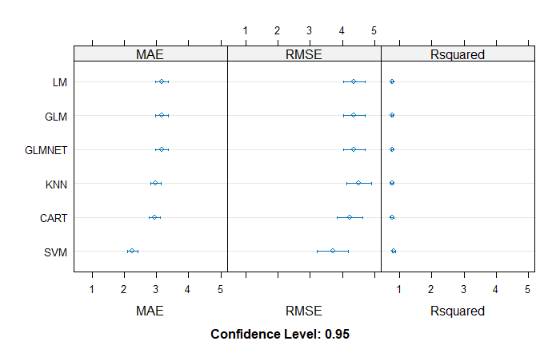

```r
dotplot(transformResults)
```

# Improve model with tuning

We can improve the accuracy of the well performing algorithms by tuning their parameters. In this section we will look at tuning the parameters of SVM with a Radial Basis Function (RBF). with more time it might be worth exploring tuning of the parameters for CART and KNN. It might also be worth exploring other kernels for SVM besides the RBF. Let’s look at the default parameters already adopted.

# Display estimated accuracy of a model

```r
print(fit.svm)
```

```
Support Vector Machines with Radial Basis Function Kernel

407 samples
 13 predictor

Pre-processing: centered (13), scaled (13), Box-Cox transformation (11)
Resampling: Cross-Validated (10 fold, repeated 3 times)
Summary of sample sizes: 365, 366, 366, 367, 366, 366, ...
Resampling results across tuning parameters:

  C     RMSE      Rsquared   MAE
  0.25  4.540024  0.7717394  2.731571
  0.50  4.073572  0.8016482  2.459453
  1.00  3.702897  0.8274159  2.259221

Tuning parameter 'sigma' was held constant at a value of 0.1160954
RMSE was used to select the optimal model using the smallest value.
The final values used for the model were sigma = 0.1160954 and C = 1.
```

Let’s design a grid search around a C value of 1. We might see a small trend of decreasing RMSE with increasing C, so let’s try all integer C values between 1 and 10. Another parameter that caret lets us tune is the sigma parameter. This is a smoothing parameter. Good sigma values are often start around 0.1, so we will try numbers before and after.

# Tune the parameters of a model.

```r
# tune SVM sigma and C parameters

trainControl <- trainControl(method="repeatedcv", number=10, repeats=3)
metric <- "RMSE"
set.seed(7)
grid <- expand.grid(.sigma=c(0.025, 0.05, 0.1, 0.15), .C=seq(1, 10,
by=1))
fit.svm <- train(medv~., data=dataset, method="svmRadial", metric=metric,
tuneGrid=grid,
preProc=c("BoxCox"), trControl=trainControl)
print(fit.svm)
```

```
Support Vector Machines with Radial Basis Function Kernel

407 samples
 13 predictor

Pre-processing: Box-Cox transformation (11)
Resampling: Cross-Validated (10 fold, repeated 3 times)
Summary of sample sizes: 365, 366, 366, 367, 366, 366, ...
Resampling results across tuning parameters:

  sigma  C   RMSE      Rsquared   MAE
  0.025   1  3.666043  0.8304251  2.341464
  0.025   2  3.493628  0.8402429  2.210608
  0.025   3  3.448027  0.8424578  2.166475
  0.025   4  3.421134  0.8441250  2.144822
  0.025   5  3.406023  0.8452104  2.126361
  0.025   6  3.396596  0.8459419  2.118039
  0.025   7  3.392730  0.8458421  2.112808
  0.025   8  3.389535  0.8456315  2.109806
  0.025   9  3.381037  0.8459219  2.107856
  0.025  10  3.369434  0.8466299  2.103481
  0.050   1  3.610080  0.8333388  2.253360
  0.050   2  3.441528  0.8431029  2.172318
  0.050   3  3.360002  0.8478343  2.111491
  0.050   4  3.302564  0.8519628  2.081684
  0.050   5  3.245578  0.8563020  2.054521
  0.050   6  3.197392  0.8597917  2.032993
  0.050   7  3.162971  0.8623836  2.024649
  0.050   8  3.132003  0.8645481  2.016135
  0.050   9  3.111908  0.8658503  2.009976
  0.050  10  3.097578  0.8667604  2.006334
  0.100   1  3.682911  0.8286388  2.256098
  0.100   2  3.369351  0.8482277  2.120290
  0.100   3  3.231527  0.8577559  2.059342
  0.100   4  3.168919  0.8623427  2.043215
  0.100   5  3.137567  0.8645176  2.038875
  0.100   6  3.112662  0.8663073  2.037551
  0.100   7  3.094980  0.8675240  2.038389
  0.100   8  3.086051  0.8679036  2.039479
  0.100   9  3.080897  0.8682378  2.040387
  0.100  10  3.084181  0.8680824  2.045987
  0.150   1  3.785244  0.8219277  2.301245
  0.150   2  3.415474  0.8464298  2.141562
  0.150   3  3.296697  0.8543834  2.090340
  0.150   4  3.258625  0.8567102  2.088175
  0.150   5  3.236921  0.8575635  2.092287
  0.150   6  3.228499  0.8576468  2.102106
  0.150   7  3.228241  0.8573974  2.115081
  0.150   8  3.242664  0.8563191  2.133669
  0.150   9  3.260328  0.8550405  2.153824
  0.150  10  3.273906  0.8540664  2.170337

RMSE was used to select the optimal model using the smallest value.
The final values used for the model were sigma = 0.1 and C = 9.
```

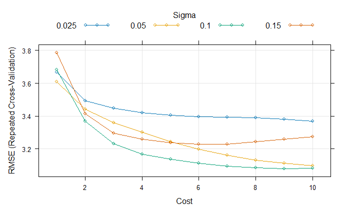

```r
plot(fit.svm)
```

```r
NA
NA
```

If we wanted to take this further, we could try even more fine tuning with more grid searches. We could also explore trying to tune other parameters of the underlying ksvm() function. Finally and as already mentioned, we could perform some grid searches on the other non-linear regression methods

# Ensemble Methods

We can try some ensemble methods on the problem and see if we can get a further decrease in our RMSE. In this section we will look at some boosting and bagging techniques for decision trees. Additional approaches you could look into would be blending the predictions of multiple well performing models together, called stacking. Let’s take a look at the following ensemble methods:

Random Forest, bagging (RF). Gradient Boosting Machines boosting (GBM). Cubist, boosting (CUBIST).

# Estimate accuracy of ensemble methods

```r
# try ensemble

trainControl <- trainControl(method="repeatedcv", number=10, repeats=3)
metric <- "RMSE"

# Random Forest
set.seed(7)
fit.rf <- train(medv~., data=dataset, method="rf", metric=metric,
preProc=c("BoxCox"), trControl=trainControl)

# Stochastic Gradient Boosting
set.seed(7)
fit.gbm <- train(medv~., data=dataset, method="gbm", metric=metric,
preProc=c("BoxCox"), trControl=trainControl, verbose=FALSE)
```

```
1 package is needed and is not installed. (gbm). Would you like to try to install it now?
1: yes
2: no
```

```r
1
# Cubist
set.seed(7)
fit.cubist <- train(medv~., data=dataset, method="cubist", metric=metric,
preProc=c("BoxCox"), trControl=trainControl)
```

```
1 package is needed and is not installed. (Cubist). Would you like to try to install it now?
1: yes
2: no
```

```r
1
# Compare algorithms
ensembleResults <- resamples(list(RF=fit.rf, GBM=fit.gbm,
CUBIST=fit.cubist))
summary(ensembleResults)
```

```
Call:
summary.resamples(object = ensembleResults)

Models: RF, GBM, CUBIST
Number of resamples: 30

MAE
           Min.  1st Qu.   Median     Mean  3rd Qu.     Max. NA's
RF     1.636635 1.977145 2.200994 2.210221 2.302417 3.220658    0
GBM    1.646824 1.979192 2.265152 2.327776 2.545692 3.752348    0
CUBIST 1.311433 1.754070 1.952186 2.000247 2.173831 2.891565    0

RMSE
           Min.  1st Qu.   Median     Mean  3rd Qu.     Max. NA's
RF     2.112991 2.575385 3.076901 3.218102 3.695468 6.521859    0
GBM    1.917678 2.544770 3.310917 3.379109 3.665515 6.851109    0
CUBIST 1.786686 2.379441 2.738151 3.087677 3.779192 5.788691    0

Rsquared
            Min.   1st Qu.    Median      Mean   3rd Qu.      Max. NA's
RF     0.5972355 0.8517322 0.9004050 0.8685981 0.9188907 0.9724223    0
GBM    0.5581867 0.8154935 0.8886156 0.8508565 0.9120289 0.9643755    0
CUBIST 0.6805940 0.8176997 0.9092059 0.8754041 0.9318374 0.9699312    0
```

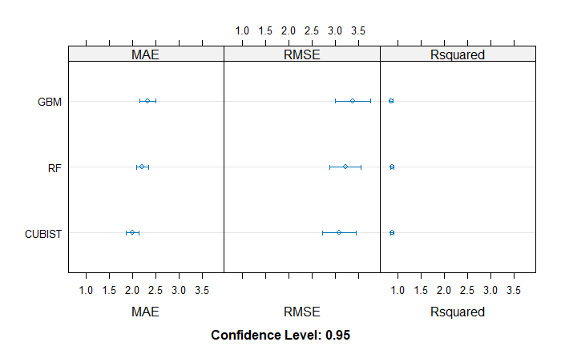

```r
dotplot(ensembleResults)
```

We can see that Cubist was the most accurate.

Let’s dive deeper into Cubist and see if we can tune it further and get more skill out of it. Cubist has two parameters that are tuneable with caret: committees which is the number of boosting operations and neighbours which is used during prediction and is the number of instances used to correct the rule based prediction (although the documentation is perhaps a little ambiguous on this). For more information about Cubist see the help on the function ?cubist. Let’s first look at the default tuning parameter used by caret that resulted in our accurate model.

# Summarize accuracy of a model.

```r
# look at parameters used for Cubist
print(fit.cubist)
```

```
Cubist

407 samples
 13 predictor

Pre-processing: Box-Cox transformation (11)
Resampling: Cross-Validated (10 fold, repeated 3 times)
Summary of sample sizes: 365, 366, 366, 367, 366, 366, ...
Resampling results across tuning parameters:

  committees  neighbors  RMSE      Rsquared   MAE
   1          0          3.935283  0.8050980  2.501518
   1          5          3.663278  0.8278677  2.239888
   1          9          3.685088  0.8254836  2.257340
  10          0          3.449718  0.8480935  2.288926
  10          5          3.191849  0.8675510  2.044831
  10          9          3.229558  0.8643281  2.074724
  20          0          3.339729  0.8576020  2.247981
  20          5          3.087677  0.8754041  2.000247
  20          9          3.122622  0.8723800  2.031336

RMSE was used to select the optimal model using the smallest value.
The final values used for the model were committees = 20 and neighbors = 5.
```

We can see that the best RMSE was achieved with committees = 20 and neighbors = 5

RMSE was used to select the optimal model using the smallest value. The final values used for the model were committees = 20 and neighbors = 5.

Let’s use a grid search to tune around those values. We’ll try all committees between 15 and 25 and spot-check a neighbours value above and below 5.

# Tune the parameters of a model.

```r
# Tune the Cubist algorithm
trainControl <- trainControl(method="repeatedcv", number=10, repeats=3)
metric <- "RMSE"
set.seed(7)
grid <- expand.grid(.committees=seq(15, 25, by=1), .neighbors=c(3, 5, 7))
tune.cubist <- train(medv~., data=dataset, method="cubist",
metric=metric,
preProc=c("BoxCox"), tuneGrid=grid, trControl=trainControl)
print(tune.cubist)
```

```
Cubist

407 samples
 13 predictor

Pre-processing: Box-Cox transformation (11)
Resampling: Cross-Validated (10 fold, repeated 3 times)
Summary of sample sizes: 365, 366, 366, 367, 366, 366, ...
Resampling results across tuning parameters:

  committees  neighbors  RMSE      Rsquared   MAE
  15          3          3.073937  0.8767747  1.995981
  15          5          3.128523  0.8727199  2.016761
  15          7          3.140179  0.8711152  2.029532
  16          3          3.054057  0.8778157  1.988389
```

[output cut: 32 more lines]

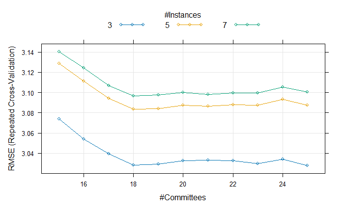

```r
plot(tune.cubist)
```

We can see that we have achieved a more accurate model again with an RMSE of 3.028333 using committees = 18 and neighbors = 3

RMSE was used to select the optimal model using the smallest value. The final values used for the model were committees = 18 and neighbors = 3.

With more time we could tune the Cubist algorithm further. Also, with results like this, it also suggests it might be worth investigating whether we can get more out of the GBM or other boosting implementations.

# Finalise the Model

It looks like that cubist results in our most accurate model. Let’s finalise it by creating a new standalone Cubist model with the parameters above trained using the whole dataset. We must also use the Box-Cox power transform.

# Prepare the data transform and finalize the model

```r
# prepare the data transform using training data

library(Cubist)

set.seed(7)

x <- dataset[,1:13]
y <- dataset[,14]
preprocessParams <- preProcess(x, method=c("BoxCox"))
transX <- predict(preprocessParams, x)
# train the final model
finalModel <- cubist(x=transX, y=y, committees=18)
summary(finalModel)
```

```
Call:
cubist.default(x = transX, y = y, committees = 18)


Cubist [Release 2.07 GPL Edition]  Thu Jul 25 02:18:21 2024
---------------------------------

    Target attribute `outcome'

Read 407 cases (14 attributes) from undefined.data

Model 1:

  Rule 1/1: [84 cases, mean 14.29, range 5 to 27.5, est err 1.97]

    if
    nox > -0.4864544
    then
    outcome = 35.08 - 2.45 crim - 4.31 lstat + 2.1e-05 b

  Rule 1/2: [163 cases, mean 19.37, range 7 to 31, est err 2.10]

    if
    nox <= -0.4864544
    lstat > 2.848535
    then
    outcome = 186.8 - 2.34 lstat - 3.3 dis - 88 tax + 2 rad + 4.4 rm
              - 0.033 ptratio - 0.0116 age + 3.3e-05 b

  Rule 1/3: [24 cases, mean 21.65, range 18.2 to 25.3, est err 1.19]

    if
    rm <= 3.326479
    dis > 1.345056
    lstat <= 2.848535
    then
    outcome = 43.83 + 14.5 rm - 2.29 lstat - 3.8 dis - 30 tax
              - 0.014 ptratio - 1.4 nox + 0.017 zn + 0.4 rad + 0.15 crim
              - 0.0025 age + 8e-06 b

```

[output cut: 968 more lines]

```
       72%    84%    lstat
       38%    85%    dis
       35%    80%    rm
       27%    55%    nox
        4%    58%    crim
        2%    49%    b
        2%    68%    ptratio
        1%    78%    tax
        1%    67%    age
              41%    rad
              36%    indus
              20%    zn


Time: 0.1 secs
```

We can now use this model to evaluate our held-out validation dataset. Again, we must prepare the input data using the same Box-Cox transform.

# Make predictions using the final model

```r
# transform the validation dataset

set.seed(7)
valX <- validation[,1:13]
trans_valX <- predict(preprocessParams, valX)
valY <- validation[,14]

# use final model to make predictions on the validation dataset

predictions <- predict(finalModel, newdata=trans_valX, neighbors=3)

# calculate RMSE

rmse <- RMSE(predictions, valY)
r2 <- R2(predictions, valY)
print(rmse)
```

```
[1] 3.237403
```

## Lab2: Binary Classification Machine Learning Project

# Import packages

```r
library(dplyr)
library(tidyr)
library(corrgram)
library(ggplot2)
library(ggthemes)
library(cluster)
library(caret)
library(ggplot2)

# Insert dataset into R

med <- read.csv("cancer_data.csv", sep = ",", header = TRUE)

# Discard the id column as it will not be used in any of the analysis below

med <- med[, 2:12]

# change the name of the first column to diagnosis

colnames(med)[1] <- "diagnosis"
```

# EDA

Exploratory Data Analysis and Visualisations Before using the machine learning algorithms for classification task, it is essential to have an overview of the dataset. Below there is a box-plot of each predictor against the target variable (tumour). The log value of the predictors used instead of the actual values, for a better view of the plot.

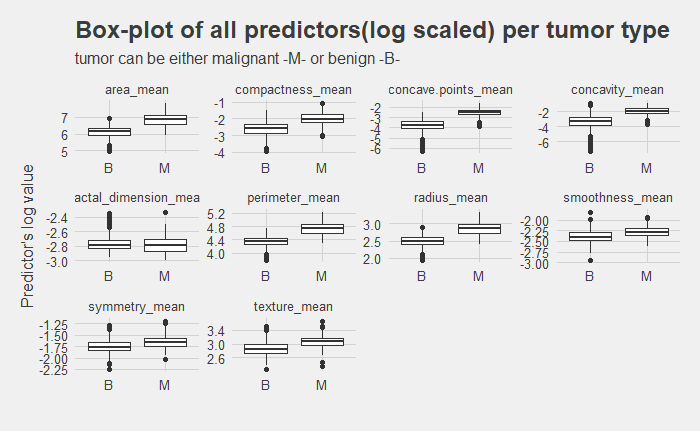

```r
# Create a long version of the dataset
med2 <- gather(med, "feature", "n", 2:11)
ggplot(med2)+
geom_boxplot(aes(diagnosis, log(n)))+
facet_wrap(~feature, scales = "free")+
labs(title = "Box-plot of all predictors(log scaled) per tumor type",
subtitle = "tumor can be either malignant -M- or benign -B-")+
theme_fivethirtyeight()+
theme(axis.title = element_text()) +
ylab("Predictor's log value") +
xlab('')
```

It seems that for most predictors the malignant level of tumour type has higher values than the benign level. Now let’s see if the predictors are correlated. Below there is a scatter-plot matrix of all predictors

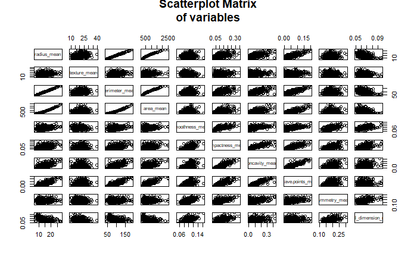

```r
# Scatterplot matrix of all numeric variables
pairs(~., data = med[, sapply(med, is.numeric)], main = "Scatterplot Matrix
of variables")
```

We can observe how there are some predictors that are strongly related, as expected, such as radius, perimeter, and area. A correlogram will serve us better and quantify all correlations.

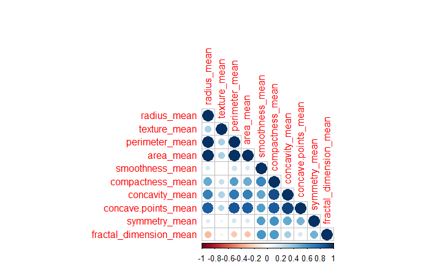

```r
library(corrplot)
# Plot correlogram of numeric variables
corrplot(cor(med[,2:11]), type="lower", tl.srt = 90)
```

We can spot some less significant correlations, such as concave and concavity and compactness. Also concave against radius, perimeter, and area.

# Making prediction using classification methods

In the first part of this analysis, the goal is to predict whether the tumour is malignant or benign based on the variables produced by the digitized image using classification methods. Classification tasks consists of identifying to which of a set of categories (sub-populations) a new observation belongs, on the basis of a training set of data containing observations (or instances) whose category membership is known. Thus, we need to develop a model that classifies (categorise) each tumour (case) to either malignant or benign. Classification will be performed with two different methods, Logistic Regression and Decision Trees.

# Feature selection

It is important to use only significant predictors while building the prediction model. You do not need to use every feature at your disposal for creating an algorithm. You can assist the algorithm

by feeding in only those features that are really important. Below there are some reasons for the feature selection: It enables the machine learning algorithm to train faster. It reduces the complexity of a model and makes it easier to interpret. It improves the accuracy of a model if the right subset is chosen. It reduces over-fitting.

In particular, I used the stepwise (forward & backward) logistic regression on the data, since the dataset is small. This method is computationally very expensive, so it is not recommended for very large datasets.

```r
library(MASS)

# Encode diagnosis to 0(B) 1(M)


#med$diagnosis <- ifelse(med$diagnosis == 'B', 0, 1)
med$diagnosis <- as.factor(med$diagnosis)

# Create a logistic regression model

glm <- glm(diagnosis ~ ., family=binomial(link='logit'), data = med)
# Run the stepwise regression

both <- stepAIC(glm, direction = "both")
```

```
Start:  AIC=168.13
diagnosis ~ radius_mean + texture_mean + perimeter_mean + area_mean +
    smoothness_mean + compactness_mean + concavity_mean + concave.points_mean +
    symmetry_mean + fractal_dimension_mean
```

```
                         Df Deviance    AIC
- compactness_mean        1   146.14 166.14
- perimeter_mean          1   146.15 166.15
- radius_mean             1   146.44 166.44
- fractal_dimension_mean  1   146.78 166.78
- concavity_mean          1   147.23 167.23
<none>                        146.13 168.13
- symmetry_mean           1   148.44 168.44
- area_mean               1   151.63 171.63
- concave.points_mean     1   151.93 171.93
- smoothness_mean         1   152.42 172.42
- texture_mean            1   195.34 215.34
```

```
Step:  AIC=166.14
diagnosis ~ radius_mean + texture_mean + perimeter_mean + area_mean +
    smoothness_mean + concavity_mean + concave.points_mean +
    symmetry_mean + fractal_dimension_mean
```

```
                         Df Deviance    AIC
- perimeter_mean          1   146.22 164.22
- radius_mean             1   146.52 164.52
- concavity_mean          1   147.25 165.25
- fractal_dimension_mean  1   147.27 165.27
<none>                        146.14 166.14
- symmetry_mean           1   148.46 166.46
+ compactness_mean        1   146.13 168.13
- concave.points_mean     1   151.93 169.93
- area_mean               1   152.00 170.00
- smoothness_mean         1   152.45 170.45
- texture_mean            1   195.48 213.48
```

```
Step:  AIC=164.22
diagnosis ~ radius_mean + texture_mean + area_mean + smoothness_mean +
    concavity_mean + concave.points_mean + symmetry_mean + fractal_dimension_mean
```

```
                         Df Deviance    AIC
- concavity_mean          1   147.28 163.28
<none>                        146.22 164.22
- fractal_dimension_mean  1   148.30 164.30
- symmetry_mean           1   148.52 164.52
+ perimeter_mean          1   146.14 166.14
+ compactness_mean        1   146.15 166.15
- radius_mean             1   150.19 166.19
- concave.points_mean     1   152.19 168.19
- area_mean               1   153.35 169.35
- smoothness_mean         1   153.39 169.39
- texture_mean            1   195.93 211.93
```

```
Step:  AIC=163.28
diagnosis ~ radius_mean + texture_mean + area_mean + smoothness_mean +
    concave.points_mean + symmetry_mean + fractal_dimension_mean
```

```
                         Df Deviance    AIC
- fractal_dimension_mean  1   148.38 162.38
<none>                        147.28 163.28
- symmetry_mean           1   150.03 164.03
+ concavity_mean          1   146.22 164.22
+ compactness_mean        1   147.24 165.24
+ perimeter_mean          1   147.25 165.25
- radius_mean             1   153.04 167.04
- smoothness_mean         1   153.61 167.61
- area_mean               1   156.64 170.64
- concave.points_mean     1   170.51 184.51
- texture_mean            1   197.40 211.40
```

```
Step:  AIC=162.39
diagnosis ~ radius_mean + texture_mean + area_mean + smoothness_mean +
    concave.points_mean + symmetry_mean
```

```
                         Df Deviance    AIC
<none>                        148.38 162.38
- symmetry_mean           1   150.68 162.68
+ fractal_dimension_mean  1   147.28 163.28
+ compactness_mean        1   147.45 163.45
+ perimeter_mean          1   147.74 163.74
+ concavity_mean          1   148.30 164.30
- radius_mean             1   153.44 165.44
- smoothness_mean         1   154.44 166.44
- area_mean               1   157.38 169.38
- concave.points_mean     1   172.31 184.31
- texture_mean            1   198.83 210.83
```

```r
# Print the summary of the stepwise model

summary(both)
```

```
Call:
glm(formula = diagnosis ~ radius_mean + texture_mean + area_mean +
    smoothness_mean + concave.points_mean + symmetry_mean, family = binomial(link = "logit"),
    data = med)

Coefficients:
                    Estimate Std. Error z value      Pr(>|z|)
(Intercept)         -8.61085    8.33550  -1.033       0.30159
radius_mean         -2.72515    1.17554  -2.318       0.02044 *
texture_mean         0.38522    0.06430   5.991 0.00000000209 ***
area_mean            0.04308    0.01428   3.017       0.00255 **
smoothness_mean     58.37855   23.49622   2.485       0.01297 *
concave.points_mean 73.70154   16.21489   4.545 0.00000548571 ***
symmetry_mean       15.56212   10.25705   1.517       0.12921
---
Signif. codes:  0 ‘***’ 0.001 ‘**’ 0.01 ‘*’ 0.05 ‘.’ 0.1 ‘ ’ 1

(Dispersion parameter for binomial family taken to be 1)

    Null deviance: 751.44  on 568  degrees of freedom
Residual deviance: 148.39  on 562  degrees of freedom
AIC: 162.39

Number of Fisher Scoring iterations: 9
```